# Clustering — Café Arábica

K-means y HDBSCAN sobre scores PCA · Coffee Quality Institute

Juan Sebastián Guayazán · Esteban Valente · Diego Nocua

26 de octubre de 2026

> **Propósito:** aplicar métodos de clustering sobre los scores PCA de los 1.070 lotes de café arábica. Se comparan dos enfoques: **K-means** (partición esférica, k fijo) y **HDBSCAN** (densidad jerárquica, k automático, detecta ruido).

# 1. Preparación de datos

```r
library(dplyr)
library(factoextra)
library(dbscan)      # incluye hdbscan()
library(ggplot2)
library(car)

# ── Pipeline idéntico al informe_despues.Rmd ──────────────────────────────────
data_raw <- read.csv("../data/arabica_data_cleaned.csv")

vars_originales <- c("Aroma", "Flavor", "Aftertaste", "Acidity", "Body",
                     "Balance", "Uniformity", "Clean.Cup", "Sweetness",
                     "Cupper.Points", "Moisture", "Category.One.Defects",
                     "Category.Two.Defects", "altitude_mean_meters")

datos_full <- data_raw %>%
  filter(!is.na(altitude_mean_meters),
         altitude_mean_meters > 0,
         altitude_mean_meters <= 3000) %>%
  select(all_of(vars_originales)) %>%
  filter(complete.cases(.)) %>%
  rename(
    Sabor           = Flavor,
    Retrogusto      = Aftertaste,
    Acidez          = Acidity,
    Cuerpo          = Body,
    Uniformidad     = Uniformity,
    Taza.Limpia     = Clean.Cup,
    Dulzura         = Sweetness,
    Puntaje.Catador = Cupper.Points,
    Humedad         = Moisture,
    Defectos.Cat1   = Category.One.Defects,
    Defectos.Cat2   = Category.Two.Defects,
    Altitud         = altitude_mean_meters
  )

yj_transform <- function(x, lambda) {
  if (lambda != 0) ((x + 1)^lambda - 1) / lambda else log(x + 1)
}
datos_full$Defectos.Cat2 <- yj_transform(datos_full$Defectos.Cat2, -0.217)

vars_11 <- setdiff(names(datos_full), c("Defectos.Cat1", "Defectos.Cat2", "Humedad"))
datos_t <- datos_full[, vars_11]

pt_11      <- powerTransform(datos_t, family = "yjPower")
lambdas_11 <- pmax(pmin(coef(pt_11, round = FALSE), 3), -3)
for (v in names(datos_t)) datos_t[[v]] <- yjPower(datos_t[[v]], lambdas_11[v])

pca <- prcomp(datos_t, center = TRUE, scale. = TRUE)

# Matriz de scores — se usará como X para clustering
X <- pca$x
cat("Dimensiones de X (scores PCA):", nrow(X), "lotes ×", ncol(X), "componentes\n")
```

```
## Dimensiones de X (scores PCA): 1070 lotes × 11 componentes
```

# 2. K-means

## 2.1. Estandarización

K-means usa distancias euclidianas, por lo que los scores ya están en escala comparable. Si se trabajara sobre las variables originales sería necesario `scale()`.

```r
# Los scores PCA ya tienen media ≈ 0, pero se re-escalan por seguridad
X_stand <- scale(X)
```

## 2.2. Elección de k — método WSS (codo)

El método del codo calcula la **suma de cuadrados intra-cluster (WSS)** para cada k. A medida que k crece, WSS siempre baja; el punto óptimo es donde la curva “dobla” — a partir de ahí añadir más clusters da poco beneficio.

```r
set.seed(42)
k_max <- 10

# Calcular WSS para cada k
wss_vals <- sapply(1:k_max, function(k) {
  kmeans(X_stand, centers = k, nstart = 25)$tot.withinss
})

# Detectar el codo: mayor caída relativa de WSS
caidas      <- -diff(wss_vals)                 # cuánto baja WSS al pasar de k a k+1
caidas_rel  <- caidas / wss_vals[-length(wss_vals)]  # caída relativa
aceleracion <- diff(caidas_rel)                # segunda diferencia
k_codo      <- which.max(-aceleracion) + 1    # k donde la caída se frena más

cat("k sugerido por el método del codo:", k_codo, "\n")
```

```
## k sugerido por el método del codo: 8
```

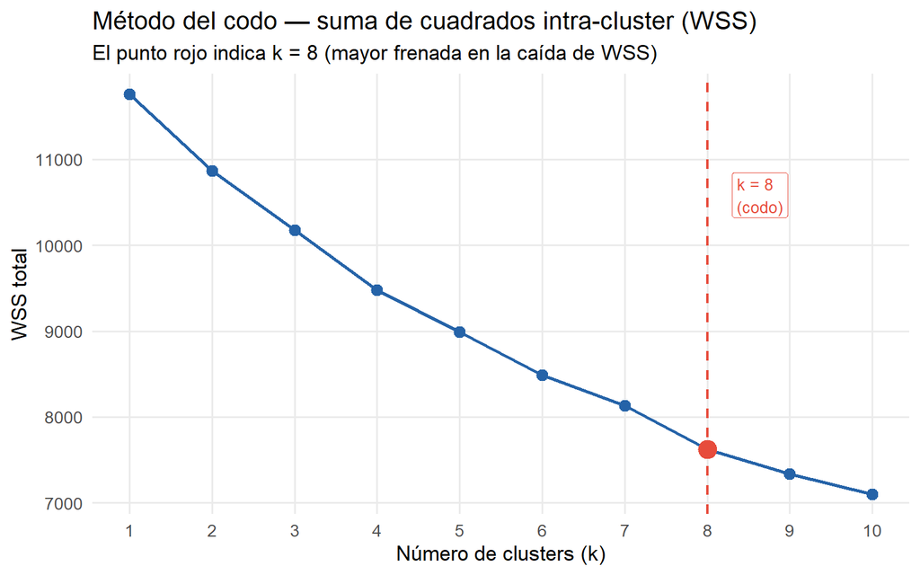

```r
# Gráfico con línea marcando el k elegido
wss_df <- data.frame(k = 1:k_max, wss = wss_vals)
ggplot(wss_df, aes(x = k, y = wss)) +
  geom_line(color = "#2563a8", linewidth = 1) +
  geom_point(color = "#2563a8", size = 3) +
  geom_point(data = wss_df[k_codo, ], aes(x = k, y = wss),
             color = "#e74c3c", size = 5) +
  geom_vline(xintercept = k_codo, linetype = "dashed",
             color = "#e74c3c", linewidth = 0.8) +
  annotate("label", x = k_codo + 0.3, y = max(wss_vals) * 0.9,
           label = paste0("k = ", k_codo, "\n(codo)"),
           color = "#e74c3c", size = 3.5, hjust = 0) +
  scale_x_continuous(breaks = 1:k_max) +
  labs(title    = "Método del codo — suma de cuadrados intra-cluster (WSS)",
       subtitle = paste0("El punto rojo indica k = ", k_codo, " (mayor frenada en la caída de WSS)"),
       x = "Número de clusters (k)",
       y = "WSS total") +
  theme_minimal(base_size = 13) +
  theme(panel.grid.minor = element_blank())
```

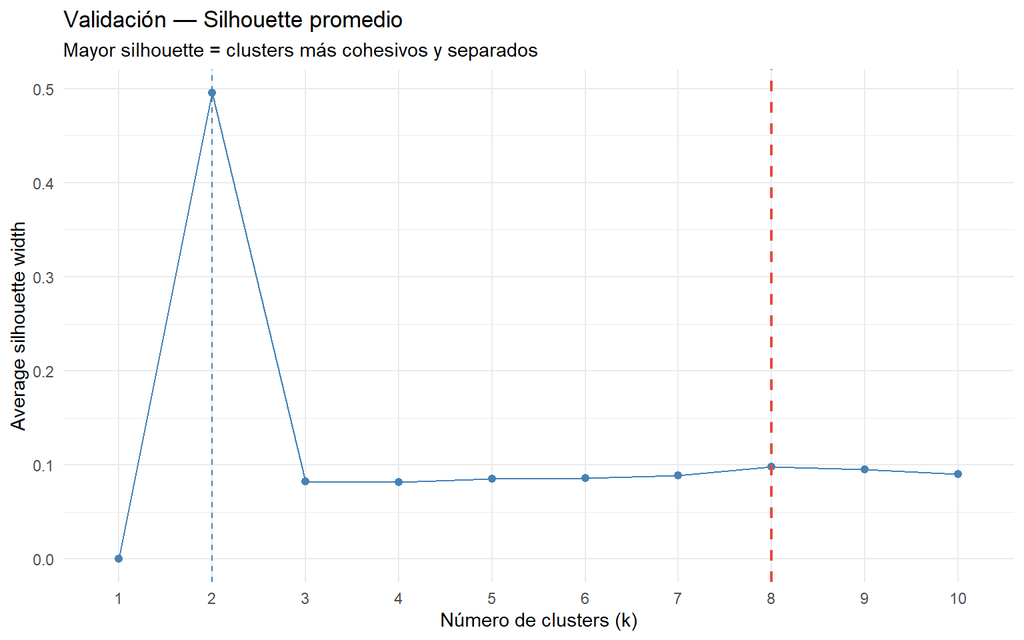

```r
# Silhouette como validación: mayor valor = mejor separación entre clusters
fviz_nbclust(X_stand, kmeans,
             method  = "silhouette",
             k.max   = k_max,
             nstart  = 25) +
  labs(title    = "Validación — Silhouette promedio",
       subtitle = "Mayor silhouette = clusters más cohesivos y separados",
       x = "Número de clusters (k)") +
  geom_vline(xintercept = k_codo, linetype = "dashed",
             color = "#e74c3c", linewidth = 0.8) +
  theme_minimal()
```

## 2.3. Ajuste del modelo final

```r
# k_optimo se deriva directamente del análisis del codo
k_optimo <- k_codo
cat("k seleccionado:", k_optimo, "\n")
```

```
## k seleccionado: 8
```

```r
set.seed(42)
km <- kmeans(X_stand, centers = k_optimo, nstart = 25)

cat("Tamaño de cada cluster:\n")
```

```
## Tamaño de cada cluster:
```

```r
print(km$size)
```

```
## [1]  27 208 302  17 173 286  20  37
```

```r
cat("\nRatio BSS/TSS (varianza explicada por clusters):",
    round(km$betweenss / km$totss * 100, 1), "%\n")
```

```
##
## Ratio BSS/TSS (varianza explicada por clusters): 35 %
```

## 2.4. Visualización en el plano CP1–CP2

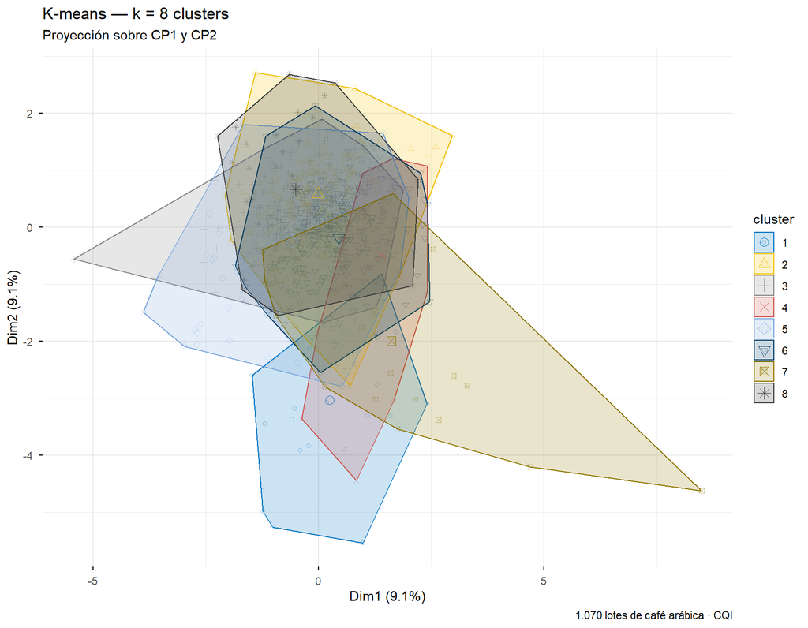

```r
fviz_cluster(km, data = X_stand,
             geom        = "point",
             ellipse.type = "convex",
             palette     = "jco",
             alpha       = 0.4,
             ggtheme     = theme_minimal()) +
  labs(title    = paste0("K-means — k = ", k_optimo, " clusters"),
       subtitle = "Proyección sobre CP1 y CP2",
       caption  = "1.070 lotes de café arábica · CQI")
```

## 2.5. Perfil de cada cluster

```r
datos_t$cluster_km <- factor(km$cluster)

perfil_km <- datos_t %>%
  group_by(cluster_km) %>%
  summarise(across(where(is.numeric), mean), .groups = "drop")

perfil_km
```

| cluster_km | Aroma | Sabor | Retrogusto | Acidez | Cuerpo | Balance | Uniformidad | Taza.Limpia | Dulzura | Puntaje.Catador | Altitud |
| --- | --- | --- | --- | --- | --- | --- | --- | --- | --- | --- | --- |
| 1 | 200.8957 | 105.26436 | 81.78613 | 197.4932 | 198.2609 | 56.92146 | 248.2797 | 361.5819 | 440.5099 | 42.03141 | 10684.705 |
| 2 | 208.9037 | 110.57160 | 87.23077 | 202.6576 | 205.7482 | 61.09591 | 438.2023 | 441.5499 | 441.5008 | 44.44647 | 5794.908 |
| 3 | 207.4285 | 110.92778 | 87.99765 | 202.1894 | 204.7476 | 61.85221 | 440.3042 | 441.8526 | 441.8188 | 44.98136 | 14733.068 |
| 4 | 182.8804 | 93.27200 | 71.35161 | 187.3437 | 193.0959 | 54.33193 | 414.7934 | 114.5944 | 430.4811 | 37.29122 | 10231.139 |
| 5 | 237.0148 | 126.63070 | 95.86268 | 237.7128 | 218.6269 | 66.42439 | 437.1642 | 440.6894 | 438.9268 | 48.96702 | 13757.713 |
| 6 | 202.9286 | 108.36880 | 79.68796 | 203.7392 | 201.4135 | 58.90687 | 435.6392 | 439.3351 | 441.2010 | 42.25656 | 11854.801 |
| 7 | 184.6742 | 93.03344 | 70.17938 | 179.1329 | 179.3168 | 51.94593 | 301.6934 | 288.0236 | 216.9117 | 37.62131 | 11629.538 |
| 8 | 215.2926 | 112.38625 | 85.28160 | 196.8822 | 211.0502 | 74.65720 | 427.9893 | 437.1523 | 433.0317 | 45.68358 | 12579.520 |

# 3. HDBSCAN

HDBSCAN (*Hierarchical Density-Based Spatial Clustering of Applications with Noise*) identifica clusters de densidad variable sin necesidad de especificar k. Los puntos en zonas de baja densidad se clasifican como **ruido** (cluster 0).

```r
# minPts equivale a min_cluster_size en Python's hdbscan
hdb <- hdbscan(X_stand, minPts = 20)

cat("Clusters encontrados (sin contar ruido):",
    length(unique(hdb$cluster[hdb$cluster > 0])), "\n")
```

```
## Clusters encontrados (sin contar ruido): 0
```

```r
cat("\nDistribución de puntos por cluster (0 = ruido):\n")
```

```
##
## Distribución de puntos por cluster (0 = ruido):
```

```r
print(table(hdb$cluster))
```

```
##
##    0
## 1070
```

[figure not shown]

```r
scores_plot <- as.data.frame(X_stand[, 1:2])
colnames(scores_plot) <- c("CP1", "CP2")
scores_plot$cluster_hdb <- factor(hdb$cluster)
scores_plot$ruido       <- hdb$cluster == 0

ggplot(scores_plot, aes(x = CP1, y = CP2, color = cluster_hdb)) +
  geom_point(aes(alpha = ifelse(ruido, 0.2, 0.5), shape = ruido), size = 1.5) +
  scale_alpha_identity() +
  scale_shape_manual(values = c(`FALSE` = 16, `TRUE` = 4),
                     labels  = c("Cluster", "Ruido"),
                     name    = "") +
  scale_color_brewer(palette = "Set1", name = "Cluster") +
  geom_hline(yintercept = 0, linetype = "dashed", color = "#ccc") +
  geom_vline(xintercept = 0, linetype = "dashed", color = "#ccc") +
  labs(title    = "HDBSCAN — clustering de densidad jerárquica",
       subtitle = paste0("minPts = 20  ·  ",
                         sum(hdb$cluster == 0), " puntos clasificados como ruido"),
       caption  = "1.070 lotes de café arábica · CQI",
       x = "CP1 (Calidad sensorial general)",
       y = "CP2 (Consistencia vs. intensidad)") +
  theme_minimal(base_size = 13) +
  theme(panel.grid.minor = element_blank())
```

## 3.1. Perfil de cada cluster HDBSCAN

```r
datos_t$cluster_hdb <- factor(hdb$cluster)

perfil_hdb <- datos_t %>%
  filter(cluster_hdb != 0) %>%   # excluir ruido
  group_by(cluster_hdb) %>%
  summarise(across(where(is.numeric), mean), .groups = "drop")

perfil_hdb
```

| cluster_hdb | Aroma | Sabor | Retrogusto | Acidez | Cuerpo | Balance | Uniformidad | Taza.Limpia | Dulzura | Puntaje.Catador | Altitud |
| --- | --- | --- | --- | --- | --- | --- | --- | --- | --- | --- | --- |

# 4. Comparación K-means vs HDBSCAN

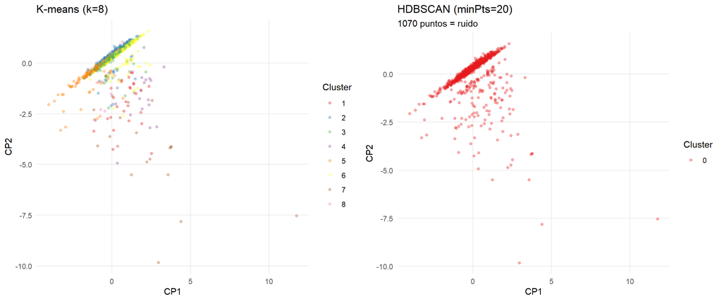

| Criterio | K-means | HDBSCAN |
| --- | --- | --- |
| Nº de clusters | Fijo (elegido por WSS) | Automático |
| Forma de clusters | Esférica (convexos) | Arbitraria |
| Manejo de ruido | No — todo punto pertenece a un cluster | Sí — puntos de baja densidad = ruido |
| Sensible a outliers | Sí | No |
| Parámetro principal | k | minPts |

```r
scores_comp <- as.data.frame(X_stand[, 1:2])
colnames(scores_comp) <- c("CP1", "CP2")
scores_comp$kmeans  <- factor(km$cluster)
scores_comp$hdbscan <- factor(hdb$cluster)

p1 <- ggplot(scores_comp, aes(CP1, CP2, color = kmeans)) +
  geom_point(alpha = 0.35, size = 1.2) +
  scale_color_brewer(palette = "Set1") +
  labs(title = paste0("K-means (k=", k_optimo, ")"), color = "Cluster") +
  theme_minimal() + theme(panel.grid.minor = element_blank())

p2 <- ggplot(scores_comp, aes(CP1, CP2, color = hdbscan)) +
  geom_point(alpha = 0.35, size = 1.2) +
  scale_color_brewer(palette = "Set1") +
  labs(title = "HDBSCAN (minPts=20)",
       subtitle = paste0(sum(hdb$cluster == 0), " puntos = ruido"),
       color = "Cluster") +
  theme_minimal() + theme(panel.grid.minor = element_blank())

gridExtra::grid.arrange(p1, p2, ncol = 2)
```